# PROJECT 1 - Energy Indicators

```r
# However, is there an actual correlation? I use the cor() function from the last lecture to get an idea of the correlation among some of the variables of interest: overall gdp, total energy consumption, total energy production, consumption per capita and gdp per capita.

rel_matrix <- cor(
  energy_sub |>
    select(gdp, primary_energy_consumption, total_energy_production, energy_per_capita, gdp_per_capita))

rel_matrix
```

```
##                                  gdp primary_energy_consumption
## gdp                        1.0000000                  0.9535673
## primary_energy_consumption 0.9535673                  1.0000000
## total_energy_production    0.8646430                  0.9344654
## energy_per_capita          0.1469512                  0.1898656
## gdp_per_capita             0.2238584                  0.2063156
##                            total_energy_production energy_per_capita
## gdp                                      0.8646430         0.1469512
## primary_energy_consumption               0.9344654         0.1898656
## total_energy_production                  1.0000000         0.2248695
## energy_per_capita                        0.2248695         1.0000000
## gdp_per_capita                           0.2159420         0.7712503
##                            gdp_per_capita
## gdp                             0.2238584
## primary_energy_consumption      0.2063156
## total_energy_production         0.2159420
## energy_per_capita               0.7712503
## gdp_per_capita                  1.0000000
```

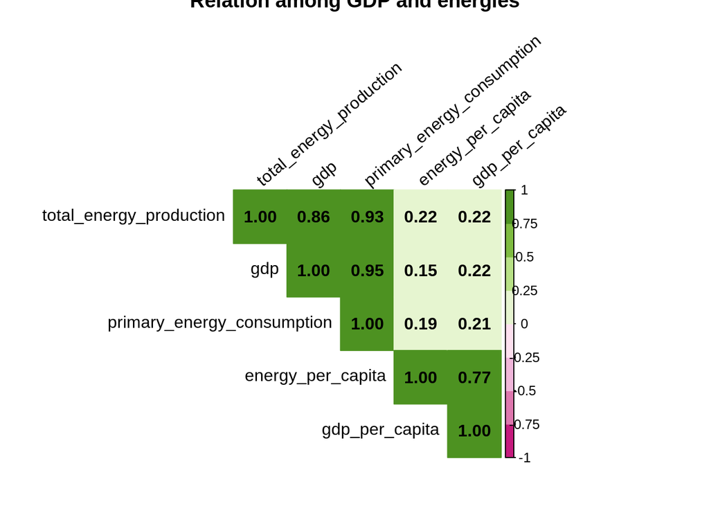

```r
corrplot(rel_matrix, method = "color", type = "upper", order = "hclust",
         tl.col = "black", tl.srt = 40, addCoef.col = "black", col = brewer.pal(n = 8, name = "PiYG"),
         title = "Relation among GDP and energies")
```

```r
# Let's look at how energies and gdp have progressed since the 60s. I'll bin de data by decade. To lump years by decade, I use an old programming trick: round down to the nearest integer with the trunc() function, so e.g., 1998 is rounded to 1990.

decadal_progress <- energy_sub |>
    mutate (decade = trunc (year/10) * 10) |>                                  # var that identifies the decade for each row
    group_by(country, decade) |>                                               # grouped by country and decade
    summarize(
      tot_population = sum(population),                                        # get total and avg population
      avg_population = mean (population),
      tot_energy_consumption = sum(primary_energy_consumption),                # get total and avg energies
      avg_energy_consumption = mean(primary_energy_consumption),
      tot_energy_production = sum(total_energy_production),
      avg_energy_production = mean(total_energy_production),
      tot_gdp = sum(gdp),                                                      # get total and avg gdp
      avg_gdp = mean(gdp),
      avg_gdp_per_capita = mean(gdp_per_capita)                                # as well as avg gdp per capita
    )
 decadal_progress
```

```
## # A tibble: 937 × 11
## # Groups:   country [165]
##    country     decade tot_population avg_population tot_energy_consumption
##    <chr>        <dbl>          <dbl>          <dbl>                  <dbl>
##  1 Afghanistan   1980      115838139      11583814.                  139.
##  2 Afghanistan   1990      161086026      16108603.                   98.7
##  3 Afghanistan   2000      237773210      23777321                    79.6
##  4 Afghanistan   2010      331427064      33142706.                  360.
##  5 Afghanistan   2020      119648094      39882698                   140.
##  6 Albania       1980       29978402       2997840.                  417.
##  7 Albania       1990       32522462       3252246.                  162.
##  8 Albania       2000       30768716       3076872.                  230.
##  9 Albania       2010       29035027       2903503.                  254.
## 10 Albania       2020        8549053       2849684.                   72.5
## # ℹ 927 more rows
## # ℹ 6 more variables: avg_energy_consumption <dbl>,
## #   tot_energy_production <dbl>, avg_energy_production <dbl>, tot_gdp <dbl>,
## #   avg_gdp <dbl>, avg_gdp_per_capita <dbl>
```

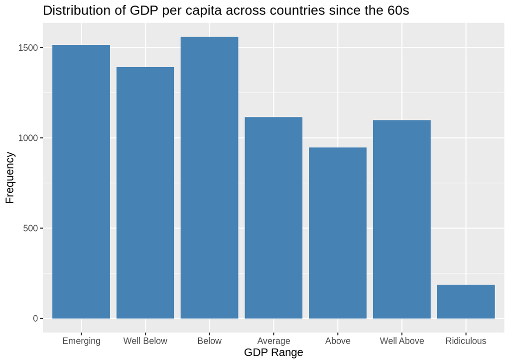

```r
# Now, let's also create bins lumping gdp_per_capita by ranges, which we can call "below avg", "average", "above avg", etc.  I had done binning before, but had to check how to do it in R with the cut() function.
# My bin cutoffs are arbitrary, but are related to the basic stats found above for gdp_per_capita (ca. min:360, 1Qu:2800, median:7800, mean:13000, 3Qu:18000, max:163000).

cutoffs <- c(360,2000,5000,10000,16000,25000,50000,Inf)
labels <- c('Emerging','Well Below','Below','Average','Above','Well Above','Ridiculous')
energy_sub$gdp_per_capita_bin <- cut(energy_sub$gdp_per_capita, breaks=cutoffs,labels=labels, include.lowest = TRUE, right = TRUE)       # create the variable: gdp_per_capita_bin

# and plot it out to find the frequency of gdp_per_capita across countries since the 60s. The net effect is to classify countries into the categories shown.

ggplot(energy_sub, aes(x = gdp_per_capita_bin)) +
  geom_bar(fill= "steelblue") +
  labs( title= 'Distribution of GDP per capita across countries since the 60s', x='GDP Range', y="Frequency")
```

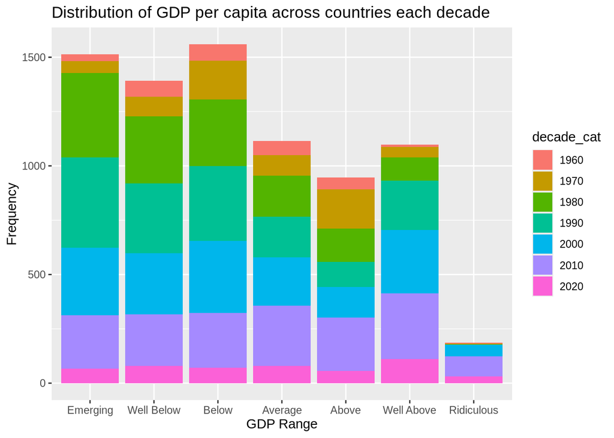

```r
# Let's try using bins in the decadal_progress data (data grouped by country and 10-year period.) The idea is to see if the histogram comes out by decade.

decadal_progress_bined <- energy_sub |>
    mutate (decade = trunc (year/10) * 10) |>
    group_by(country, decade)

decadal_progress_bined$gdp_per_capita_bin <- cut(decadal_progress_bined$gdp_per_capita, breaks=cutoffs,labels=labels, include.lowest = TRUE, right = TRUE)        # use the same breaks and labels as before

# convert variable "decade" to categorical, since we'll need it to be categorical for the histogram to work; add new column

decadal_progress_bined$decade_cat <- factor(decadal_progress_bined$decade)

ggplot(decadal_progress_bined, aes(x = gdp_per_capita_bin, fill= decade_cat)) +
  geom_bar(position= "stack") +
  labs( title= 'Distribution of GDP per capita across countries each decade', x='GDP Range', y="Frequency")
```

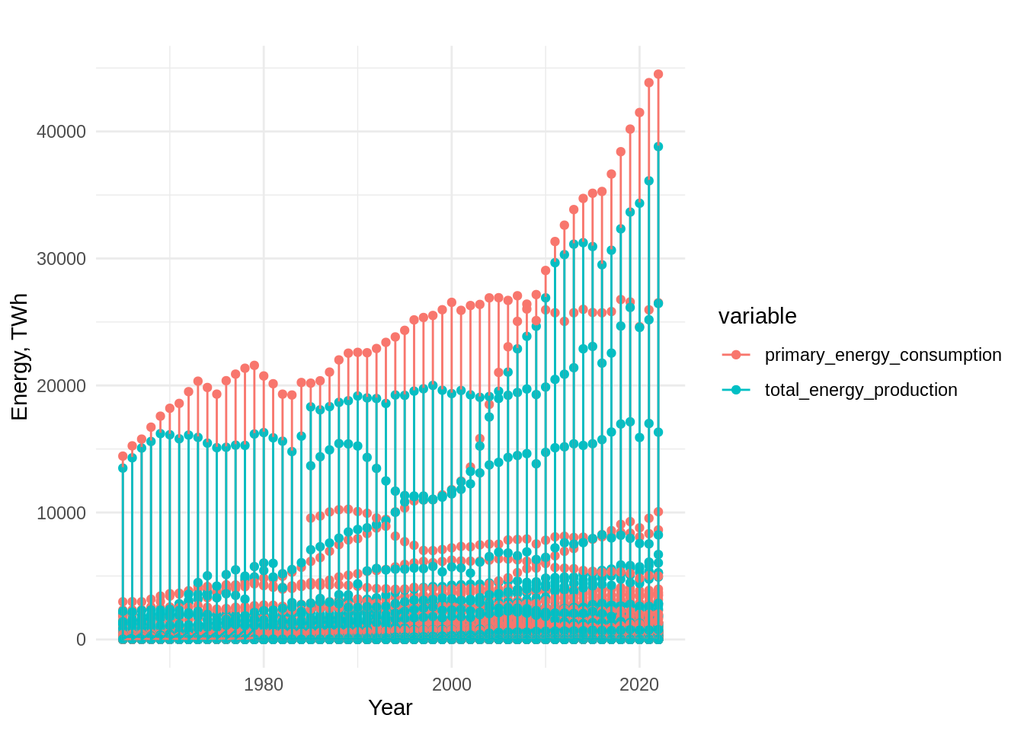

```r
# Investigate qualitatively the evolution over time of primary energy consumption and production and GDP per capita. all countries are lumped.

# First convert from "wide" to "long" format  per book instructions for the geom_point to work.

energy_long <- pivot_longer(energy_sub, cols = c(primary_energy_consumption, total_energy_production), names_to = "variable", values_to = "value")
ggplot (energy_long, aes(x = year, y = value, color = variable)) +
  geom_point() +
  geom_line() +
  labs(title = "",
       x = "Year", y = "Energy, TWh") +
  theme_minimal()
```

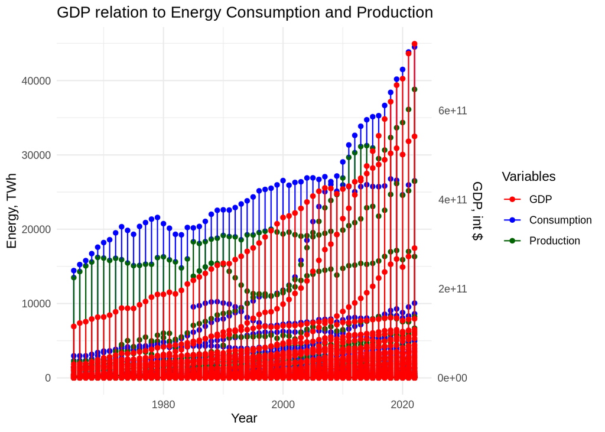

```r
# Now let's show how the gdp evolved (all counties lumped) on the right y-axis. I found by trial and error that 10^8/6 is a good scaling factor to put energy (left axis) and gdp (right axis) on the same plot

energy_long <- pivot_longer(energy_sub, cols = c(primary_energy_consumption, total_energy_production), names_to = "variable", values_to = "value")

ggplot (energy_long, aes(x = year, y= value, color=variable))+
  geom_point() +
  geom_line() +
  geom_point(aes(y=gdp/10^8/6, color="GDP")) +
  geom_line(aes(y=gdp/10^8/6, color="GDP")) +
  scale_y_continuous(
    name = "Energy, TWh",
    sec.axis= sec_axis(~.*10^8/6, name="GDP, int $")) +
    labs( title="GDP relation to Energy Consumption and Production", x="Year") +
    scale_color_manual(name = "Variables", values = c("primary_energy_consumption" = "blue", "total_energy_production" = "darkgreen", "GDP" = "red"),
    labels = c("primary_energy_consumption" = "Consumption", "total_energy_production" = "Production", "GDP" = "GDP")) +

  theme_minimal()
```

```r
# Since the plot is not definitive, let's try to answer the question of correlations between energies and gdp per capita in the form of tables.

# Tabulate the mean and median of gdp per capita, energy consumption, energy production, as well as the difference energy production minus energy consumption.  That difference distinguishes countries/years when energy was exported (difference>0) or imported (difference<0). Some countries are net importers and others net exporters.

summary_stats <- decadal_progress |>
  group_by(country) |>
    summarize(
      mean_population = round(mean(avg_population),2),
      mean_gdp = round(mean(avg_gdp_per_capita),2),
      median_gdp = round(median(avg_gdp_per_capita), 2),
      mean_en_cons = round(mean(avg_energy_consumption),2),
      median_en_cons = round(median(avg_energy_consumption), 2),
      mean_en_prod = round(mean(avg_energy_production),2),
      median_en_prod = round(median(avg_energy_production), 2),
      diff_prod_cons = round(mean_en_prod - mean_en_cons, 2)
    ) |>
  arrange (desc(mean_gdp), desc(mean_en_cons), desc(mean_en_prod), desc(diff_prod_cons))             # arrange the table in descending order of mean gdp, mean energy consumption, mean energy production, and difference production-consumption

summary_stats
```

```
## # A tibble: 165 × 9
##    country       mean_population mean_gdp median_gdp mean_en_cons median_en_cons
##    <chr>                   <dbl>    <dbl>      <dbl>        <dbl>          <dbl>
##  1 Qatar                1032459.   72747.     55504.        212.           131.
##  2 United Arab …        3952095.   49530.     38331.        546.           476.
##  3 Norway               4493872.   47905.     39583.        445.           490.
##  4 Switzerland          7154370.   40941.     37024.        306.           319.
##  5 United States      269269366.   39412.     39366.      22678.         24166.
##  6 Luxembourg            446988.   39267.     41339.         41.4           42.0
##  7 Kuwait               2249476.   37353.     33127.        230.           128.
##  8 Singapore            3689620.   35810.     29509.        434.           358.
##  9 Saudi Arabia        15588337.   34637.     28900.       1428.          1106.
## 10 Denmark              5310940.   33782.     32999.        217.           210.
## # ℹ 155 more rows
## # ℹ 3 more variables: mean_en_prod <dbl>, median_en_prod <dbl>,
## #   diff_prod_cons <dbl>
```

```r
# Get a correlation matrix of summary_stats; use the cor() and corrplot()

rel_matrix <- cor(

summary_stats |>
    select(mean_population,mean_gdp, mean_en_cons, mean_en_prod, diff_prod_cons))          # line up the ducks

rel_matrix
```

```
##                 mean_population    mean_gdp mean_en_cons mean_en_prod
## mean_population      1.00000000 -0.06073726    0.6432706   0.58723511
## mean_gdp            -0.06073726  1.00000000    0.2142108   0.21238448
## mean_en_cons         0.64327057  0.21421081    1.0000000   0.93352272
## mean_en_prod         0.58723511  0.21238448    0.9335227   1.00000000
## diff_prod_cons      -0.20834118 -0.02414820   -0.2684396   0.09476489
##                 diff_prod_cons
## mean_population    -0.20834118
## mean_gdp           -0.02414820
## mean_en_cons       -0.26843962
## mean_en_prod        0.09476489
## diff_prod_cons      1.00000000
```

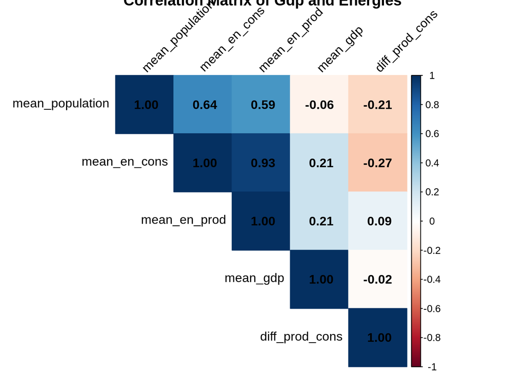

```r
corrplot(rel_matrix, method = "color", type = "upper", order = "hclust",   # and shoot them
         tl.col = "black", tl.srt = 45, addCoef.col = "black",
         title = "Correlation Matrix of Gdp and Energies")
```

### d. Conclusions

**The original question was of how the consumption of energy by countries relates to the production of energy and to their GDP, which we associated with the state of economic development of a country. We also asked how those three variables (the two energies and the national GDP) relate to the standard of living of individuals in those countries.** For the latter, we took GDP per capita to be a measure of standard of living. As stated above, this is limited; a full economic study would require other indicators and other databases. Another caveat: this is not a thorough or rigorous statistical analysis; but a subjective interpretation of tabular or graphical depictions of the data.

Before diving into the final conclusions, a note about the process. I selected a number of variables with a larger goal in mind, that of investigating groups of individual countries along their history. This quickly became unrealistic and I reduced the scope to just answering the question posed above, without identifying individual countries. The Rmarkdown above shows the tentative progression of this study; if I tried it again, I would probably include fewer steps to reach the same conclusions. I also didn’t bother to look for sophisticated dyplr functions to shorten the code.

Another note: although the database is quite complete, the authors of the dataset missed the inclusion of geothermal and marine energies, which have in the last two decades become important sources of renewable energy. Nevertheless, the dataset is quite thorough, well maintained and regularly updated. Fortunately, there was little to clean, obviously built from scratch for data science use. The NAs were for the most part indicative of information that was not collected. For example, in the 1900-1960 period very few countries maintained statistics on energy. Also, some of the NA were due to irrelevancy. For example, economic regions (like the ASEA) or continents don’t have iso_codes; and “population” or GDP for them is usually not reported, ruling out the calculation of a GDP per capita. Nevertheless, continents and economic regions are composed of countries, which are part of the database. So excluding continents and regions from this study does not alter the conclusions. The net result of the cleaning was reducing the dataset to 7800 rows.

**The first conclusion**. From the first graphical comparison that I did between GDP/capita and Energy consumption/capita, with all countries and all years included, the first impression was that there’s a strong correlation between them. However, a cor() analysis showed correlation coefficients that reveal more detail: GDP of countries correlate better with energy consumption (0.95) than with energy production (.86) which can be explained because all economic activities REQUIRE the use of energy, and not all necessitate a net positive production of energy. Many countries (e.g. Japan) strongly depend on energy imports to compensate for their deficiency of energy production and maintain their strong GDP.

### e. Obstacles

There were many obstacles, primarily with clarifying in my mind what kind of question I could **really** answer with the limited time for the project, and then sitting down to write the code and getting it to run without errors. I had to try-and-err many times, but settled for simple functions that worked. The graphics portion was OK. I had done graphics programming several years ago, so the problem was that I don’t remember any of that. I had to refresh and relearn from the texts (mainly Wickham).

### f. Future steps

I think much more can be done with this dataset. I have not had the time to check what the authors have analyzed and published. I bet it’s a ton. They have focused on the politically and technologically important energy transition issues. So while I would like to do something in that space, I bet I will just end reinventing the wheel. So I may drift away from this dataset for future projects.

The baby steps that one could still pursue with this dataset are to focus on the time domain. There are details to emerge from analyzing the evolution of energies and how they influence GDP. A new database from World Bank, UN, or others could be merged with this one to better study and understand economic variations. In terms of mechanics, I would like to decouple specific countries or groups of countries from the aggregate of nations to more clearly understand the flux of energy and associated GDP between them. The current global tensions related to that interchange show the importance of understanding this dynamics.

### g. References

- Class notes
- H. Wickham, et al., R for Data Science, 2nd Ed., https://r4ds.hadley.nz/ (2023)
- A. Douglas, et al., An Introduction to R, https://intro2r.com/ (2024)
- Energy conversion factors and facts about renewables: OSTI website (https://www.osti.gov/)

### h. Published

Published at https://rpubs.com/rmiranda/1356025